# Project: Investigate a TMDB Dataset as part of Udacity Nanodegree program

- Introduction
- Data Wrangling
- Exploratory Data Analysis
- Conclusions

## Introduction

Many of watch love to watch movies. We spend a considerable amount of time of our lives watching movies. These movies are often of different genres, budgets, directed by industry's biggest and amateur directors alike, with stellar performances by the world's greatest actors.

Over the past couple of years, movie making has grown rapidly with more and more movies being produced and consumed every year.

As Data Analysts, we not only watch movies but at the same time, can't help but wonder what goes into making these movies, how does the movie making industry work and how has it evolved through the years.

What are the top production companies and which companies rolled out the most movies?

What are some of the best and worst movies of the world so far and on what parameters?

Which movies are the most popular among viewers, which movies made the most profit and gave the most ROI figures?

Who are the most successful directors and movie stars?

Does runtime of movie matter? In today's world of hyperactivity and instant gratification behavior, the attention span of people is going down with passing time, are the changes being reflected in movies too? Is there an optimal runtime or should movie-makers just 'go for it'?

And finally what are the metrics on what revenue making capabilities of movie matter?

As part of the Investigate a dataset exercise, I am trying to find the answer to most of these questions by analysing a TMDb movies database which contains collection of about 10k+ movies, with important details including the budget, revenue, release dates among other information.

## Assumptions:

1. It is assumed that the currency of the relevant fields are in US currency, dollars for the purpose of study.
2. It is also assumed that some fields are redundant and do not contribute to the overall study results.
3. For directors and Cast Members, only the first field values are considered for the top Director and Actor category.

## Research Questions:

1. **How is the film making industry evolving?**
   - How much more movies people are consuming now compared to last few decades? (Growth Rate)
   - Is movie making a profitable business?
   - What are the some of the best and the not-so-good performing movies across different parameters through the years?
1. **Does runtime hold any importance? What is the preferred runtime of viewers?**
   - How has the average runtime of movies changed over the years?
   - What is the Average Runtime of movies currently?
   - Is there any visible relationship between Revenue and Popularity with Runtime?
1. **What are The top 10 movies of the world based on different parameters?**
1. **Genres**
   - What are the main movie genres and distribution of movies across genres?
   - How do different Genres perform across different parameters?
1. **Who are the most successful movie directors and film stars?**
   - Does having the most popular director or actor ensure financial success in the box office?
1. **Does having the most popular director or actor ensure financial success in the box office?**
1. **Which are the biggest production companies that dominate the industry?**
   - Number of movies churned by those production companies
   - Budget spending, revenue generation and ROI of those companies
1. **How does Revenue depend on different parameters?**

## Data Wrangling and Cleaning

1. Based on variables are the most appropriate and significant for answering our questions, a few columns have been removed which would not serve useful for our research purposes such as *'imdb_id', budget_adj', 'revenue_adj', 'homepage', 'keywords', 'overview'*
1. There were a few records specifically in Budget or Revenue fields with entry as '0'. Calculating profits based on these values would lead to unwanted results. So, those rows were deleted from the Data frame.
1. This dataset also has duplicate rows. These were removed for our purposes.
1. The 'Release Date' column was not in the correct Date format. These were appropriately converted.

## Data Wrangling

### Data Cleaning

```python
#Importing required Modules and extracting csv file

import pandas as pd
import numpy as np
import seaborn as sns
import matplotlib.pyplot as plt
import os
%matplotlib inline

os.chdir('C:\\Users\\Hp\\Desktop')

df = pd.read_csv('movies.csv')
```

```python
#Note: This is only for Design purposes. You may chose to ignore this part.
class color:
   PURPLE = '\033[95m'
   CYAN = '\033[96m'
   DARKCYAN = '\033[36m'
   BLUE = '\033[94m'
   GREEN = '\033[92m'
   YELLOW = '\033[93m'
   RED = '\033[91m'
   BOLD = '\033[1m'
   UNDERLINE = '\033[4m'
   END = '\033[0m'
```

```python
#This is the original data frame we are working on
df.head(2)
```

|  | id | imdb_id | popularity | budget | revenue | original_title | cast | homepage | director | tagline | ... | overview | runtime | genres | production_companies | release_date | vote_count | vote_average | release_year | budget_adj | revenue_adj |
| --- | --- | --- | --- | --- | --- | --- | --- | --- | --- | --- | --- | --- | --- | --- | --- | --- | --- | --- | --- | --- | --- |
| 0 | 135397 | tt0369610 | 32.985763 | 150000000 | 1513528810 | Jurassic World | Chris Pratt\|Bryce Dallas Howard\|Irrfan Khan\|Vi... | http://www.jurassicworld.com/ | Colin Trevorrow | The park is open. | ... | Twenty-two years after the events of Jurassic ... | 124 | Action\|Adventure\|Science Fiction\|Thriller | Universal Studios\|Amblin Entertainment\|Legenda... | 6/9/15 | 5562 | 6.5 | 2015 | 1.379999e+08 | 1.392446e+09 |
| 1 | 76341 | tt1392190 | 28.419936 | 150000000 | 378436354 | Mad Max: Fury Road | Tom Hardy\|Charlize Theron\|Hugh Keays-Byrne\|Nic... | http://www.madmaxmovie.com/ | George Miller | What a Lovely Day. | ... | An apocalyptic story set in the furthest reach... | 120 | Action\|Adventure\|Science Fiction\|Thriller | Village Roadshow Pictures\|Kennedy Miller Produ... | 5/13/15 | 6185 | 7.1 | 2015 | 1.379999e+08 | 3.481613e+08 |

2 rows × 21 columns

```python
#What are the unique column names present?
df.columns.unique()
```

```
Index(['id', 'imdb_id', 'popularity', 'budget', 'revenue', 'original_title',
       'cast', 'homepage', 'director', 'tagline', 'keywords', 'overview',
       'runtime', 'genres', 'production_companies', 'release_date',
       'vote_count', 'vote_average', 'release_year', 'budget_adj',
       'revenue_adj'],
      dtype='object')
```

```python
#Dropping Unwanted Columns
df.drop(['id', 'imdb_id', 'homepage', 'tagline', 'overview', 'budget_adj', 'revenue_adj', 'keywords'], axis = 1, inplace = True)
```

```python
#Gathering statistical Data
df.describe()
```

|  | popularity | budget | revenue | runtime | vote_count | vote_average | release_year |
| --- | --- | --- | --- | --- | --- | --- | --- |
| count | 10866.000000 | 1.086600e+04 | 1.086600e+04 | 10866.000000 | 10866.000000 | 10866.000000 | 10866.000000 |
| mean | 0.646441 | 1.462570e+07 | 3.982332e+07 | 102.070863 | 217.389748 | 5.974922 | 2001.322658 |
| std | 1.000185 | 3.091321e+07 | 1.170035e+08 | 31.381405 | 575.619058 | 0.935142 | 12.812941 |
| min | 0.000065 | 0.000000e+00 | 0.000000e+00 | 0.000000 | 10.000000 | 1.500000 | 1960.000000 |
| 25% | 0.207583 | 0.000000e+00 | 0.000000e+00 | 90.000000 | 17.000000 | 5.400000 | 1995.000000 |
| 50% | 0.383856 | 0.000000e+00 | 0.000000e+00 | 99.000000 | 38.000000 | 6.000000 | 2006.000000 |
| 75% | 0.713817 | 1.500000e+07 | 2.400000e+07 | 111.000000 | 145.750000 | 6.600000 | 2011.000000 |
| max | 32.985763 | 4.250000e+08 | 2.781506e+09 | 900.000000 | 9767.000000 | 9.200000 | 2015.000000 |

```python
#Understanding the Data types
df.info()
```

```
<class 'pandas.core.frame.DataFrame'>
RangeIndex: 10866 entries, 0 to 10865
Data columns (total 13 columns):
 #   Column                Non-Null Count  Dtype
---  ------                --------------  -----
 0   popularity            10866 non-null  float64
 1   budget                10866 non-null  int64
 2   revenue               10866 non-null  int64
 3   original_title        10866 non-null  object
 4   cast                  10790 non-null  object
 5   director              10822 non-null  object
 6   runtime               10866 non-null  int64
 7   genres                10843 non-null  object
 8   production_companies  9836 non-null   object
 9   release_date          10866 non-null  object
 10  vote_count            10866 non-null  int64
 11  vote_average          10866 non-null  float64
 12  release_year          10866 non-null  int64
dtypes: float64(2), int64(5), object(6)
memory usage: 1.1+ MB
```

```python
#Is there any duplicate rows present?
df[df.duplicated()]
```

|  | popularity | budget | revenue | original_title | cast | director | runtime | genres | production_companies | release_date | vote_count | vote_average | release_year |
| --- | --- | --- | --- | --- | --- | --- | --- | --- | --- | --- | --- | --- | --- |
| 2090 | 0.59643 | 30000000 | 967000 | TEKKEN | Jon Foo\|Kelly Overton\|Cary-Hiroyuki Tagawa\|Ian... | Dwight H. Little | 92 | Crime\|Drama\|Action\|Thriller\|Science Fiction | Namco\|Light Song Films | 3/20/10 | 110 | 5.0 | 2010 |

```python
#Dropping the Duplicated rows
df.drop_duplicates(inplace=True)
```

```python
#Is there any missing Values in the Dataset?
df[df==0].count()
```

```
popularity                 0
budget                  5696
revenue                 6016
original_title             0
cast                       0
director                   0
runtime                   31
genres                     0
production_companies       0
release_date               0
vote_count                 0
vote_average               0
release_year               0
dtype: int64
```

```python
#Replacing the 0 values with Numpy Data type NaN
df['budget'].replace(0, np.NaN, inplace = True)
df['revenue'].replace(0, np.NaN, inplace = True)
df['runtime'].replace(0, np.NaN, inplace = True)
```

```python
#Now dropping these NA values because any other technique(replacing with mean, last value etc.) doesn't make sense
df.dropna(axis=0, inplace=True)
```

```python
#Splitting the Cast, Director and Genres columns to extract the data
df_cast = (df['cast'].str.split('|', expand=True).rename(columns=lambda x: f"cast_{x+1}"))
df_dir = (df['director'].str.split('|', expand=True).rename(columns=lambda x: f"director_{x+1}"))
df_gen = (df['genres'].str.split('|', expand=True).rename(columns=lambda x: f"genres_{x+1}"))
df_prod = (df['production_companies'].str.split('|', expand=True).rename(columns=lambda x: f"production_companies_{x+1}"))

#When using expand=True, the split elements will expand out into separate columns.
```

```python
#Removing the old columns and joining back the new columns
df = df.drop(['cast', 'director', 'genres', 'production_companies'], axis = 1)
df = df.join([df_cast, df_dir, df_gen, df_prod])
```

```python
#Changing Release date type to Standard Datetime format
df.release_date = pd.to_datetime(df['release_date'])

#And the float64 types to int64 types for ease of plotting
col = ['popularity', 'budget', 'revenue', 'vote_average']
df[col] = df[col].astype(np.int64)
```

```python
#Renaming Budget, Revenue columns based on assumption of currency and adding Profit, ROI columns
df.insert(3, 'profit_US_dollars', (df['revenue'] - df['budget']))
df.insert(4, 'ROI', (df['profit_US_dollars']/df['budget']))
df.rename(columns = {'budget':'budget_US_dollars', 'revenue':'revenue_US_dollars'}, inplace = True)
```

# Exploratory Data Analysis

## First, let's look at the Number of Movies Released Each Year.

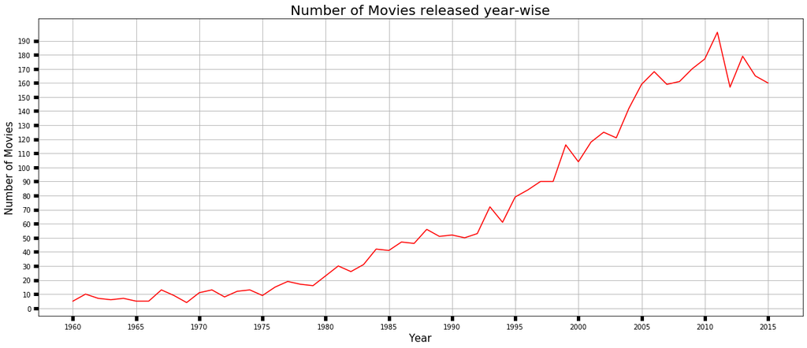

```python
#Number of movies released year-wise
data = df.groupby('release_year').count()['original_title']

params = {'figure.figsize': (20, 8), 'axes.labelsize':15, 'axes.titlesize':20}
plt.rcParams.update(params)

data.plot(xticks=np.arange(1960, 2020, 5), yticks=np.arange(0, 200, 10), c='r')

plt.title('Number of Movies released year-wise')
plt.ylabel('Number of Movies')
plt.xlabel('Year')

plt.tick_params(which='both', width=5)
plt.tick_params(which='major', length=7)

plt.grid(True, which='both', axis='both')

plt.show()
```

## Comparison of Budget, Revenue, Profit through the years

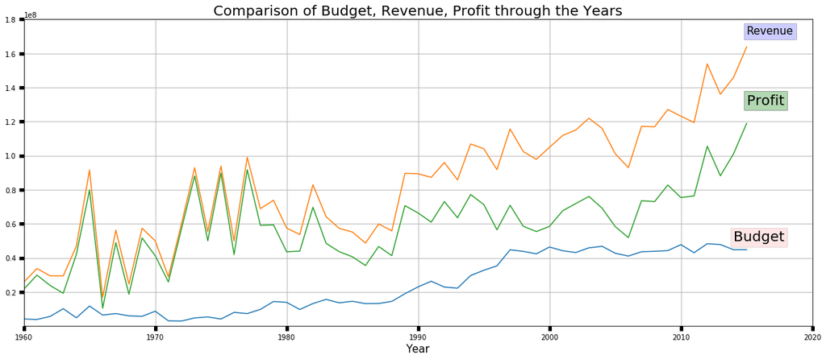

```python
(df.groupby('release_year')['budget_US_dollars']).mean().plot()
(df.groupby('release_year')['revenue_US_dollars']).mean().plot()
(df.groupby('release_year')['profit_US_dollars']).mean().plot()

params = {'figure.figsize': (20, 8), 'axes.labelsize':15, 'axes.titlesize':20}
plt.rcParams.update(params)

plt.title('Comparison of Budget, Revenue, Profit through the Years')
plt.xlabel('Year')

ax = plt.axis([1960, 2020, 1, 180000000])

plt.text(2015, 170000000, 'Revenue', verticalalignment='bottom', fontsize=15, bbox=dict(facecolor='blue', alpha=0.2))
plt.text(2015, 130000000, 'Profit', fontsize=20, bbox=dict(facecolor='green', alpha=0.3))
plt.text(2014, 50000000, 'Budget', fontsize=20, bbox=dict(facecolor='red', alpha=0.1))

plt.tick_params(which='both', width=5)
plt.tick_params(which='major', length=7)

plt.grid(True, which='both', axis='both')

plt.show()
```

## Movie with Highest and Lowest Stats across different Parameters

```python
def maxmin(val):

    min1 = df[val].idxmin()
    max1 = df[val].idxmax()

    max2 = pd.DataFrame(df.loc[max1,:])
    max2.columns = [df['original_title'][max1]]
    min2 = pd.DataFrame(df.loc[min1,:])
    min2.columns = [df['original_title'][min1]]

    print(color.BOLD + color.RED)
    print(''.join(['Movie with Highest ' + val + ' --> ', df['original_title'][max1]]), end=' --> ')
    print(df[val][max1])
    print(''.join(['Movie with Lowest ' + val + ' --> ', df['original_title'][min1]]), end=' --> ')
    print(df[val][min1])
```

```python
#Wait for it!
import time
d = str.split('popularity budget_US_dollars revenue_US_dollars profit_US_dollars ROI runtime vote_count vote_average')
print(color.BOLD + "Here are a few movie stats for the movie buffs\n")
time.sleep(0.8)

for i in d:
    maxmin(i)
    time.sleep(0.7)
    print('\n')
```

```
Here are a few movie stats for the movie buffs


Movie with Highest popularity --> Jurassic World --> 32
Movie with Lowest popularity --> Ricki and the Flash --> 0



Movie with Highest budget_US_dollars --> The Warrior's Way --> 425000000
Movie with Lowest budget_US_dollars --> Lost & Found --> 1



Movie with Highest revenue_US_dollars --> Avatar --> 2781505847
Movie with Lowest revenue_US_dollars --> Shattered Glass --> 2



Movie with Highest profit_US_dollars --> Avatar --> 2544505847
Movie with Lowest profit_US_dollars --> The Warrior's Way --> -413912431



Movie with Highest ROI --> The Karate Kid, Part II --> 1018618.2831858407
Movie with Lowest ROI --> The House of the Spirits --> -0.99999976



Movie with Highest runtime --> Carlos --> 338.0
Movie with Lowest runtime --> Kid's Story --> 15.0



Movie with Highest vote_count --> Inception --> 9767
Movie with Lowest vote_count --> Beautiful --> 10



Movie with Highest vote_average --> Inside Out --> 8
Movie with Lowest vote_average --> Foodfight! --> 2
```

## Trend of runtime of movies from 1960-2015

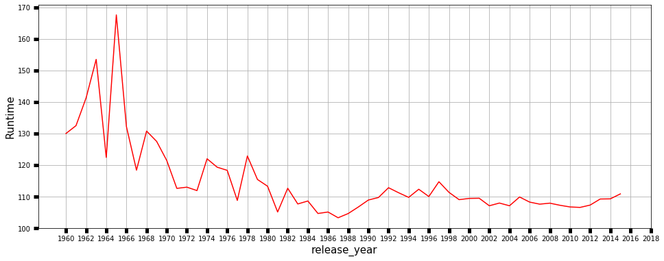

```python
po = df.groupby('release_year')['runtime'].mean()

params = {'figure.figsize': (20, 8), 'axes.labelsize':15, 'axes.titlesize':20}

plt.rcParams.update(params)
plt.title('')
plt.ylabel('Runtime')

po.plot(figsize=(16, 6), xticks=np.arange(1960, 2020, 2), yticks=np.arange(100, 180, 10), c='red')

plt.tick_params(which='both', width=5)
plt.tick_params(which='major', length=7)

plt.grid(True, which='both', axis='both')

plt.show()
```

## Average Runtime of Movies

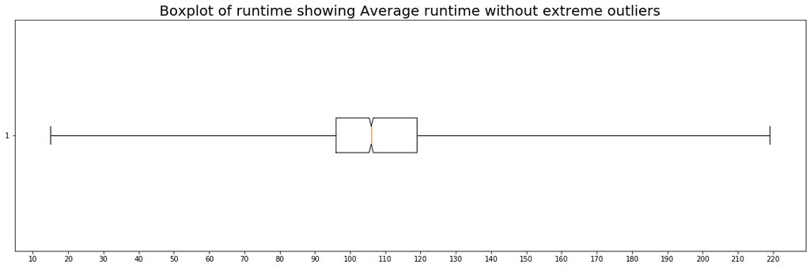

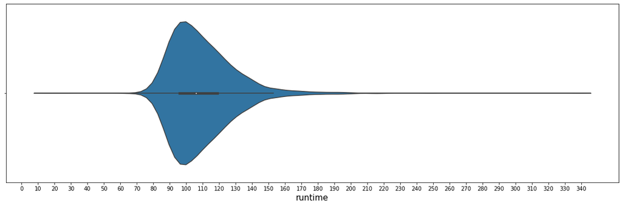

```python
params = {'figure.figsize': (20, 6), 'axes.labelsize':15, 'axes.titlesize':20}
plt.rcParams.update(params)

plt.grid(False)

plt.title('Boxplot of runtime showing Average runtime along with outliers')

plt.title('Boxplot of runtime showing Average runtime without extreme outliers')

plt.xticks(np.arange(0, 350, 10))
plt.boxplot(df.runtime, notch=True, vert=False, whis=5, showfliers=False, autorange=True)
plt.show()

plt.xticks(np.arange(0, 350, 10))

plt.grid(False)
sns.violinplot(df.runtime, notch=True, vert=False, whis=5, showfliers=True, autorange=True)
plt.show()
```

## How does Popularity and Revenue depend on Runtime?

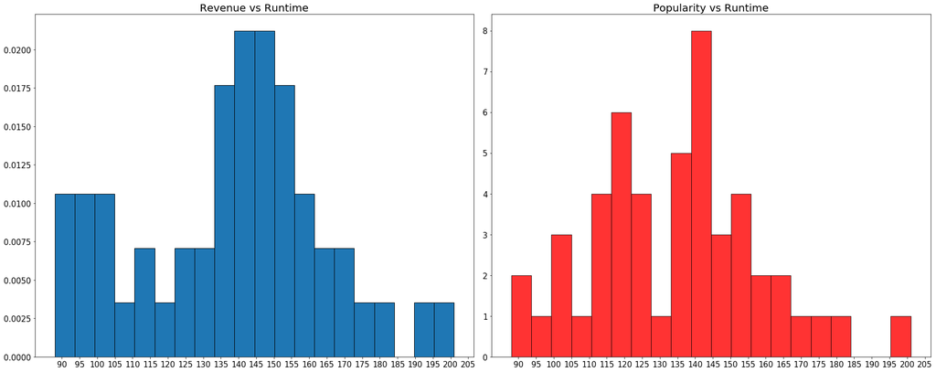

```python
test5 = df.sort_values(by='popularity', ascending=False).head(50)
test6 = df.sort_values(by='revenue_US_dollars', ascending=False).head(50)

params = {'figure.figsize': (25, 10), 'axes.labelsize':15, 'axes.titlesize':20}
plt.rcParams.update(params)

fig, (ax1, ax2) = plt.subplots(1, 2, sharex=True, sharey=False)

ax1.hist(test6.runtime, bins=20, density=True, edgecolor="k")
ax1.set_title('Revenue vs Runtime')

ax2.hist(test5.runtime, bins=20, color='Red', alpha=0.8, edgecolor="k")
ax2.set_title('Popularity vs Runtime')

plt.sca(ax1)
ax1.grid(False)
plt.yticks(fontsize=15)
plt.xticks(np.arange(90, 210, 5), fontsize=15)

plt.sca(ax2)
ax2.grid(False)
plt.yticks(fontsize=15)
plt.xticks(np.arange(90, 210, 5), fontsize=15)

plt.tight_layout()

plt.show()
```

## Comparison of Avg. Runtime and Popularity across different Genres

```python
#Here we will create a new dataframe using Melt function to compare Genres Stats'
```

```python
gen_cols = ['genres_1','genres_2', 'genres_3', 'genres_4', 'genres_5']
non_gen_cols = ['popularity', 'ROI', 'budget_US_dollars', 'revenue_US_dollars', 'profit_US_dollars', \
                'vote_count', 'vote_average', 'runtime', 'release_year']
gen_types = df.melt(id_vars=non_gen_cols, value_vars=gen_cols, var_name='gen_type', value_name='type')
```

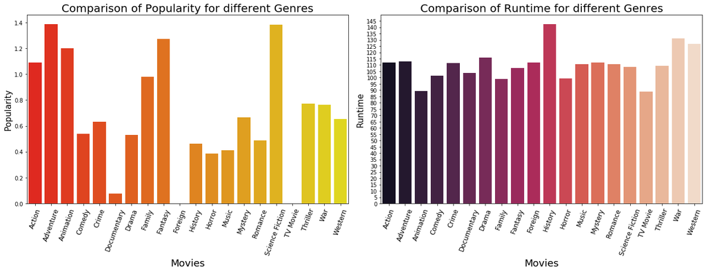

```python
a = gen_types.groupby('type')['popularity'].mean()
b = a.index

c = gen_types.groupby('type')['runtime'].mean()
d = c.index

fig, ax = plt.subplots(nrows=1, ncols=2, figsize = [18,7], sharex=True)

sns.barplot(b, a, ax=ax[0], palette='autumn')
sns.barplot(d, c, palette='rocket')

plt.sca(ax[0])
plt.xticks(fontsize=12, rotation=70)
plt.title('Comparison of Popularity for different Genres')
plt.xlabel('Movies', fontsize=18)
plt.ylabel('Popularity')

plt.sca(ax[1])
plt.xticks(fontsize=12, rotation=70)
plt.yticks(np.arange(0, 150, 5))
#Smaller Yticks were considered to better compare for trends
plt.title('Comparison of Runtime for different Genres')
plt.xlabel('Movies', fontsize=18)
plt.ylabel('Runtime')

plt.tight_layout()
plt.show()
```

## Comparison of Budget, Revenue and Profit across different Genres

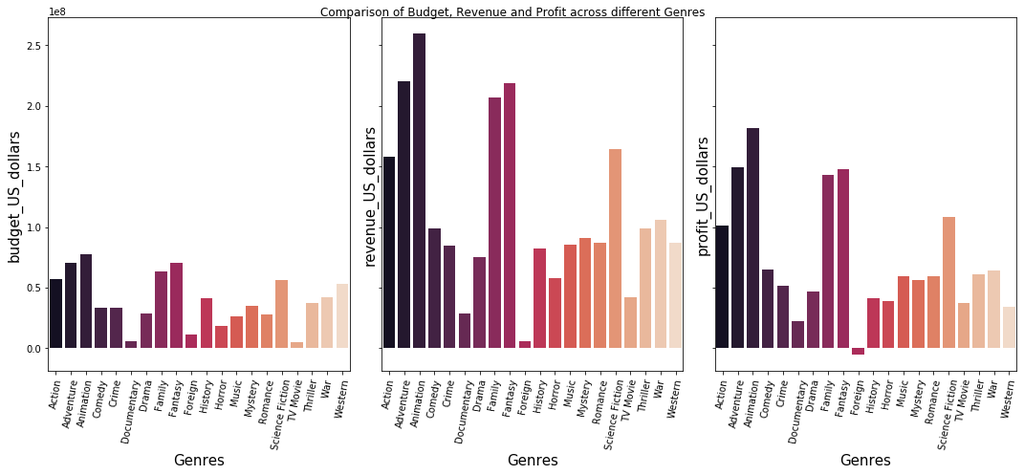

```python
fig, ax = plt.subplots(nrows=1, ncols=3, figsize=(15, 7), sharex=False, sharey=True)
plt.suptitle('Comparison of Budget, Revenue and Profit across different Genres\n')
a1 = gen_types.groupby('type')['budget_US_dollars'].mean()
b1 = a1.index
sns.barplot(b1, a1, ax=ax[0], palette='rocket')

a2 = gen_types.groupby('type')['revenue_US_dollars'].mean()
b2 = a2.index
sns.barplot(b2, a2, ax=ax[1], palette='rocket')

a3 = gen_types.groupby('type')['profit_US_dollars'].mean()
b3 = a3.index
sns.barplot(b3, a3, ax=ax[2], palette='rocket')

plt.sca(ax[0])
plt.xticks(rotation=80)
plt.xlabel('Genres')
plt.sca(ax[1])
plt.xticks(rotation=80)
plt.xlabel('Genres')
plt.sca(ax[2])
plt.xticks(rotation=80)
plt.xlabel('Genres')

plt.tight_layout()
plt.show()
```

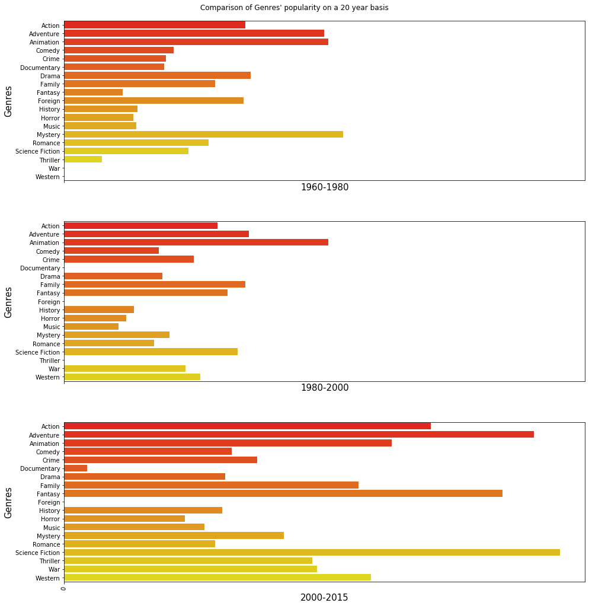

```python
fig, ax = plt.subplots(nrows=3, ncols=1, figsize=(15, 15), sharex=True, sharey=True)

plt.suptitle("Comparison of Genres' popularity on a 20 year basis")

gen_sub = gen_types.loc[gen_types['release_year'].between(1960, 1980)]
a = gen_sub.groupby('type')['popularity'].mean()
b = a.index
sns.barplot(a, b, ax=ax[0], palette='autumn')

gen_sub = gen_types.loc[gen_types['release_year'].between(1980, 2000)]
a = gen_sub.groupby('type')['popularity'].mean()
b = a.index
sns.barplot(a, b, ax=ax[1], palette='autumn')

gen_sub = gen_types.loc[gen_types['release_year'].between(2000, 2015)]
a = gen_sub.groupby('type')['popularity'].mean()
b = a.index
sns.barplot(a, b, ax=ax[2], palette='autumn')

plt.sca(ax[0])
plt.xticks(rotation=80)
plt.xlabel('1960-1980')
plt.ylabel('Genres')
plt.sca(ax[1])
plt.xticks(rotation=80)
plt.xlabel('1980-2000')
plt.ylabel('Genres')
plt.sca(ax[2])
plt.xticks(rotation=80)
plt.xlabel('2000-2015')
plt.ylabel('Genres')
plt.xticks(np.arange(0, 100, 100))

plt.tight_layout(pad=5)
plt.show()
```

## Distribution of movies across Genres

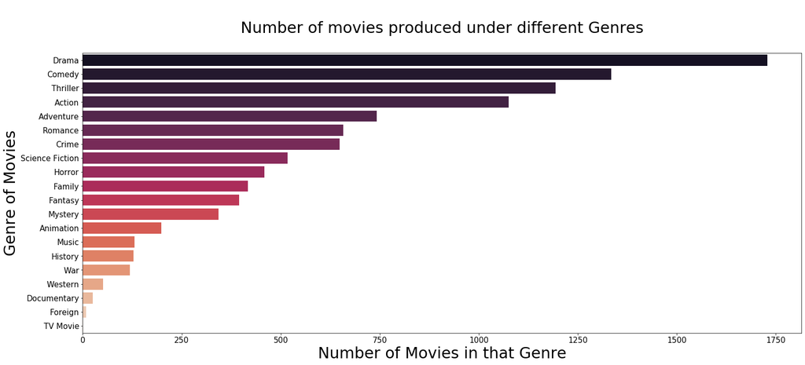

```python
type_counts = gen_types['type'].value_counts()
type_order = type_counts.index

params = {'figure.figsize': (25, 10), 'axes.labelsize':15, 'axes.titlesize':20}
plt.rcParams.update(params)

sns.countplot(data=gen_types, y='type', order=type_order, palette='rocket')

plt.title('\nNumber of movies produced under different Genres\n', fontsize=30)

plt.xticks(fontsize=15)
plt.yticks(fontsize=15)

plt.xlabel('Number of Movies in that Genre', fontsize=30)
plt.ylabel('Genre of Movies', fontsize=30)
plt.show()
```

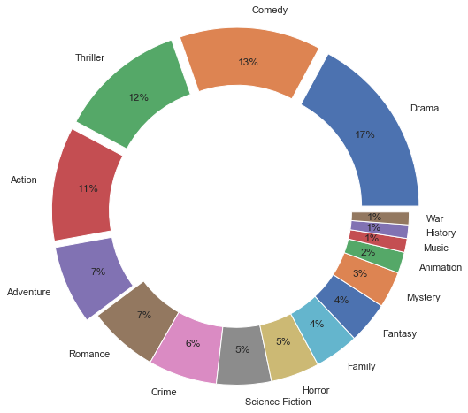

```python
labels = gen_types['type'].value_counts()[:16].index
sizes = gen_types['type'].value_counts()[:16]

explode = (0.1, 0.1, 0.1, 0.1, 0.1, 0, 0, 0, 0, 0, 0, 0, 0, 0, 0, 0)

fig1, ax1 = plt.subplots()
ax1.pie(sizes, radius=1.5, explode=explode, labels=labels, labeldistance = 1.1, pctdistance=0.8, \
         wedgeprops=dict(width=0.5), startangle=0, autopct='%1.0f%%', shadow=False)

plt.show()
```

## Top 10 Movies across different Parameters

```python
def top10(val):

    info = (df[val].sort_values(ascending=False)).head(10)

    arr = []
    for i in info.index.values:
        arr.append((df['original_title'][i], info[i]))

    arr = pd.DataFrame(arr)

    choose = {'popularity':'red', 'budget_US_dollars':'green', 'revenue_US_dollars':'blue', \
            'profit_US_dollars':'magenta', 'runtime':'purple', 'vote_count':'orange', 'ROI':'violet'}
    title = {'popularity':"Popularity", 'budget_US_dollars':'Budget', 'revenue_US_dollars':'Revenue', \
            'profit_US_dollars':'Profit', 'runtime':'Runtime', 'vote_count':'Votes', 'ROI':'ROI'}

    ax = sns.barplot(x=arr[1], y=arr[0], data=arr, color = choose[val])

    sns.set(rc={'figure.figsize':(14, 5)})
    ax.set_title('Movies with Highest ' + title[val], fontsize = 15)
    ax.set_xlabel(title[val], fontsize = 18)
    ax.set_ylabel("Movies", fontsize = 18)
    ax.grid(False)
    sns.set_style("whitegrid")
    plt.show()
```

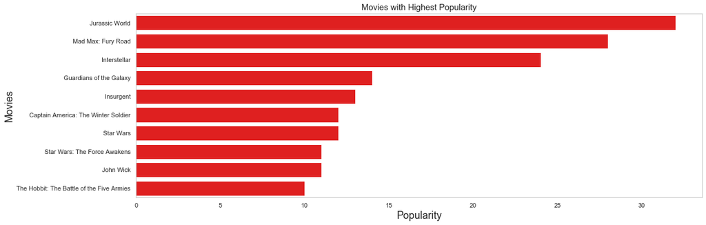

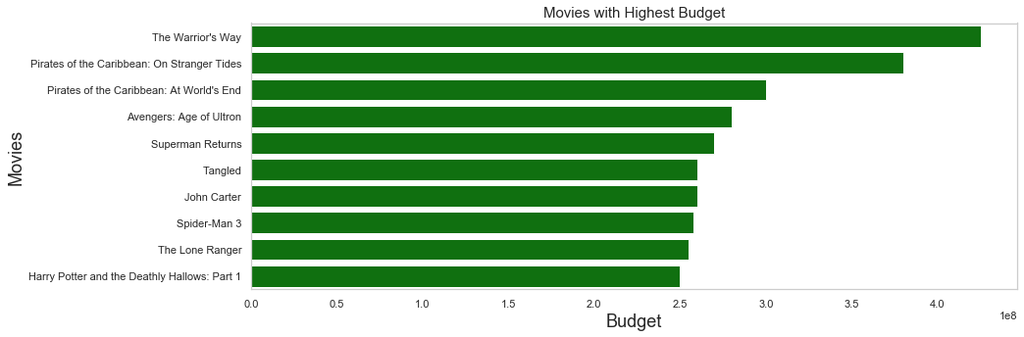

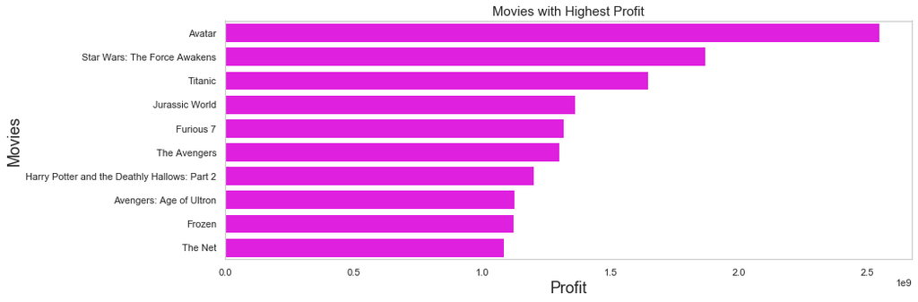

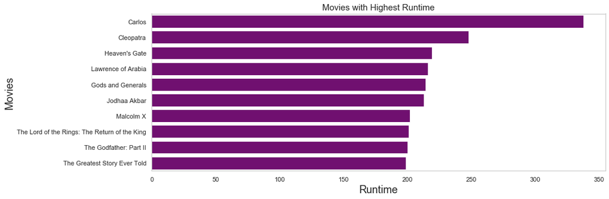

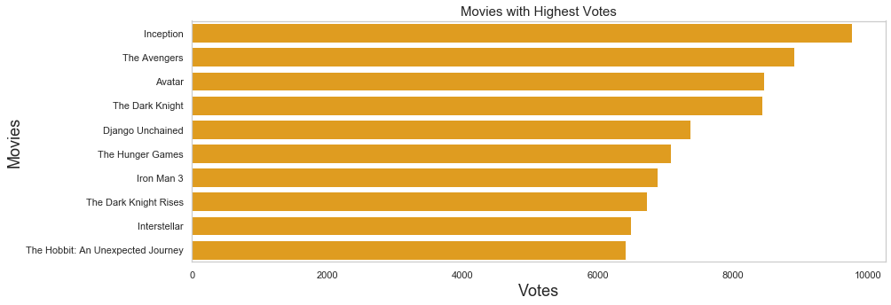

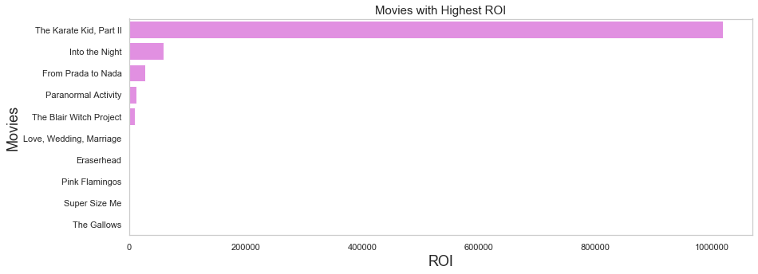

```python
top10('popularity')
top10('budget_US_dollars')
top10('profit_US_dollars')
top10('runtime')
top10('vote_count')
top10('ROI')
```

## Top Directors across different parameters

```python
def direct(val):

    test5 = df.sort_values(by=val, ascending=False)

    sns.barplot(test5[val].iloc[:20], test5.director_1.iloc[:20], palette='autumn', errwidth=0)

    params = {'figure.figsize': (14, 5), 'axes.labelsize':15, 'axes.titlesize':20}

    plt.rcParams.update(params)

    plt.title("Director with the highest " + val, fontsize=20)
    plt.xlabel(val, fontsize=25)
    plt.yticks(fontsize=15)
    plt.ylabel('Director', fontsize=25)
    plt.xticks(fontsize=15)
    plt.grid(False)

    #plt.tight_layout()

    plt.show()
```

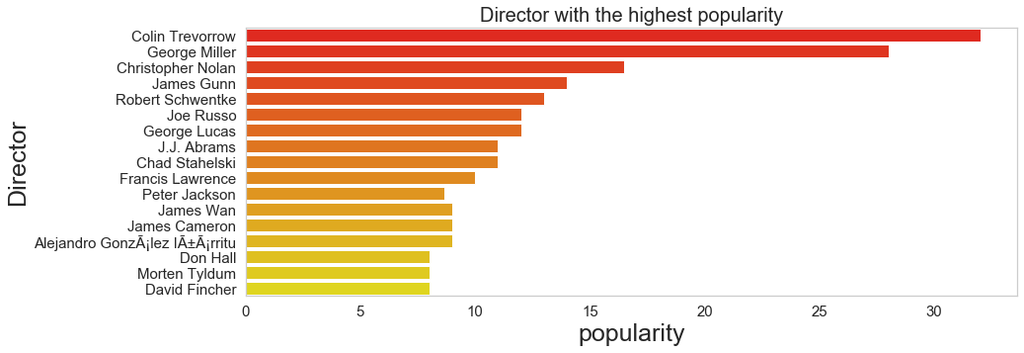

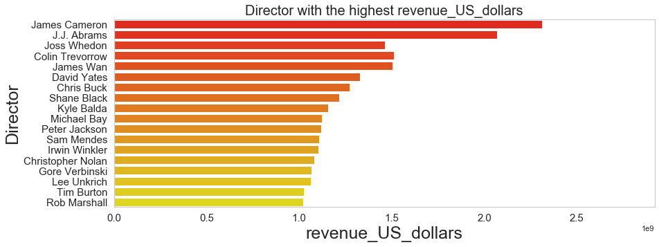

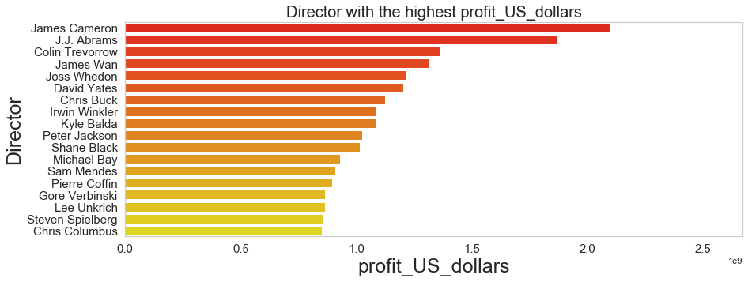

```python
direct('popularity')
direct('revenue_US_dollars')
direct('profit_US_dollars')
```

## Top Directors of the decade from 1960 to 2015

```python
def dir_year(val1, val2, val3):

    a = df[df.release_year.between(val2, val3, inclusive=True)].sort_values(by=val1, ascending=False)[val1][:20]
    b = df[df.release_year.between(val2, val3, inclusive=True)].sort_values(by=val1, ascending=False)['director_1'][:20]

    sns.barplot(a, b, palette='rocket', errwidth=False)

    params = {'figure.figsize': (18, 6), 'axes.labelsize':15, 'axes.titlesize':20}

    plt.rcParams.update(params)

    plt.title('Top 20 Directors of every decade starting from '+str(val2)+' to '+str(val3) +
              ' based on ' + val1 + '\n',
              fontsize=30)

    plt.xlabel(val1.upper(), fontsize=25)
    plt.ylabel('Directors', fontsize=25)
    plt.yticks(fontsize=15)

    plt.tight_layout()
    plt.show()
```

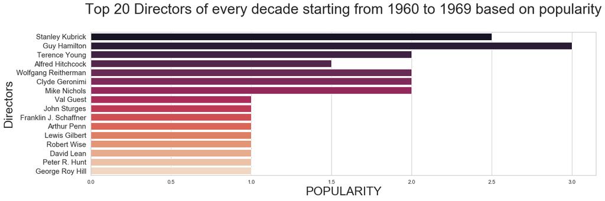

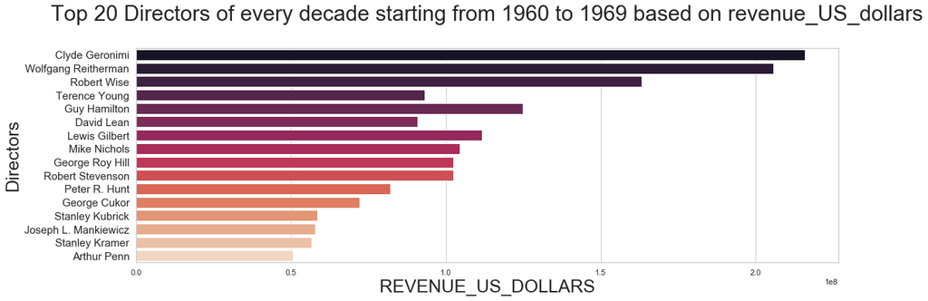

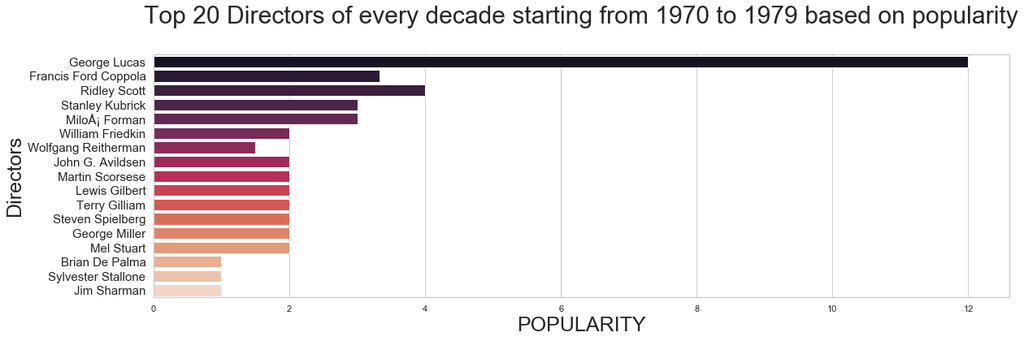

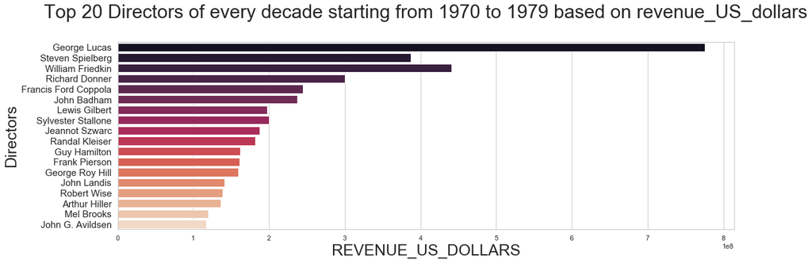

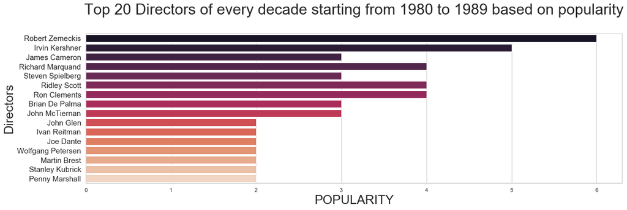

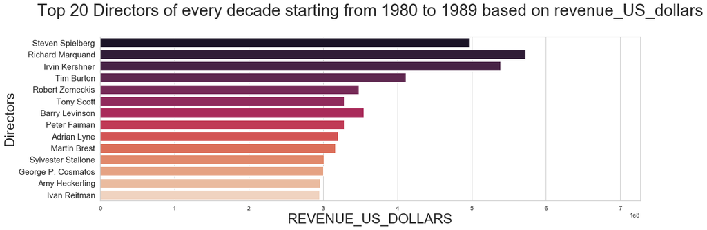

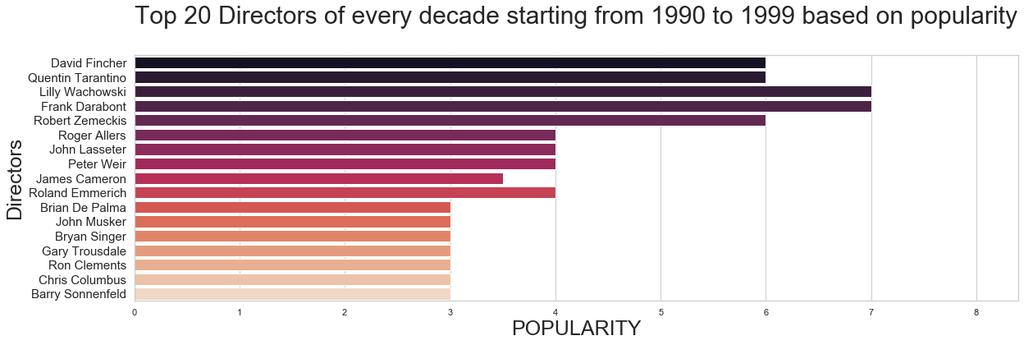

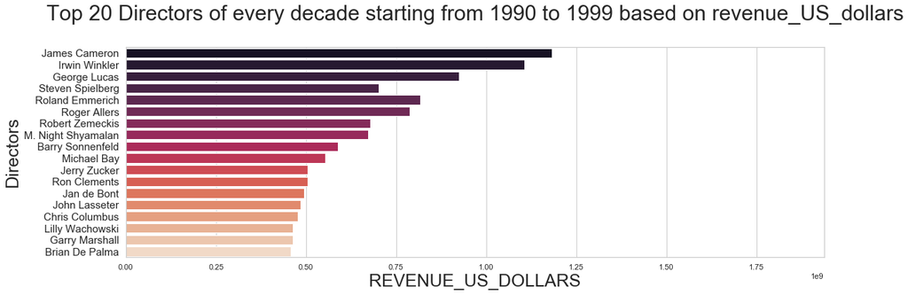

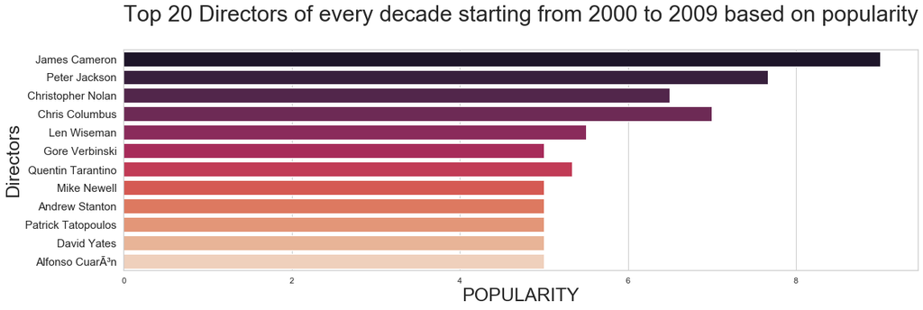

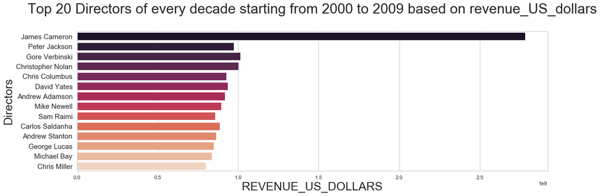

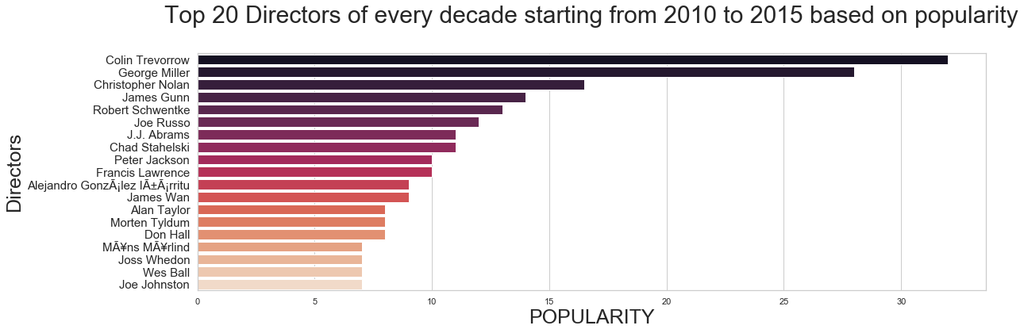

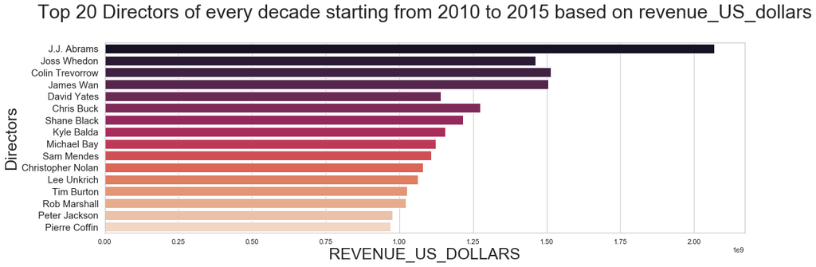

```python
dir_year('popularity', 1960, 1969)
dir_year('revenue_US_dollars', 1960, 1969)
dir_year('popularity', 1970, 1979)
dir_year('revenue_US_dollars', 1970, 1979)
dir_year('popularity', 1980, 1989)
dir_year('revenue_US_dollars', 1980, 1989)
dir_year('popularity', 1990, 1999)
dir_year('revenue_US_dollars', 1990, 1999)
dir_year('popularity', 2000, 2009)
dir_year('revenue_US_dollars', 2000, 2009)
dir_year('popularity', 2010, 2015)
dir_year('revenue_US_dollars', 2010, 2015)
```